# Soccer Data Science Challenge: Foul-Winning Probability Model

**Name:** Caio Rosa Rocha  
**Project:** Swish Analytics Soccer Challenge  
**Date:** June 2026

### This project builds a model to estimate the probability that a player wins a foul after a Ball Receipt or Ball Recovery event using EPL event data.

# Data Reading & Inspection: EPL Event Data

```python
import pandas as pd
import matplotlib.pyplot as plt
import numpy as np
```

```python
# Reading the data
# The data files should be placed in the same folder as this notebook before running the code.
df = pd.read_csv("epl_event_data_15.csv")
df_matches = pd.read_csv("epl_matches_15.csv")

# Inspecting first rows
df.head()
```

|  | Unnamed: 0 | id | index | period | timestamp | minute | second | possession | duration | related_events | ... | pass.end_location | dribble.outcome.id | dribble.outcome.name | ball_receipt.outcome.id | ball_receipt.outcome.name | carry.end_location | duel.outcome.id | duel.outcome.name | competition_id | match_id |
| --- | --- | --- | --- | --- | --- | --- | --- | --- | --- | --- | --- | --- | --- | --- | --- | --- | --- | --- | --- | --- | --- |
| 0 | 1 | 9153e9f4-f69c-4e04-8f64-505592e212cd | 1 | 1 | 00:00:00.000 | 0 | 0 | 1 | 0.000000 | NaN | ... | NaN | NaN | NaN | NaN | NaN | NaN | NaN | NaN | 2 | 3754058 |
| 1 | 2 | 3fbcf4e7-94d1-485a-be85-fd26a6af0318 | 2 | 1 | 00:00:00.000 | 0 | 0 | 1 | 0.000000 | NaN | ... | NaN | NaN | NaN | NaN | NaN | NaN | NaN | NaN | 2 | 3754058 |
| 2 | 3 | 06a9a4dc-d9c9-40f6-bd89-437ba7fe682d | 3 | 1 | 00:00:00.000 | 0 | 0 | 1 | 0.000000 | 100362ee-9311-4187-bd8a-0201d9db2565 | ... | NaN | NaN | NaN | NaN | NaN | NaN | NaN | NaN | 2 | 3754058 |
| 3 | 4 | 100362ee-9311-4187-bd8a-0201d9db2565 | 4 | 1 | 00:00:00.000 | 0 | 0 | 1 | 0.000000 | 06a9a4dc-d9c9-40f6-bd89-437ba7fe682d | ... | NaN | NaN | NaN | NaN | NaN | NaN | NaN | NaN | 2 | 3754058 |
| 4 | 5 | 2ca23eea-a984-47e4-8243-8f00880ad1c9 | 5 | 1 | 00:00:01.753 | 0 | 1 | 2 | 0.308263 | 1f98c89e-2326-4200-8c12-a987fdbbaf2e | ... | 60.4, 43.6 | NaN | NaN | NaN | NaN | NaN | NaN | NaN | 2 | 3754058 |

5 rows × 49 columns

```python
# Understanding each columns type, NAs
df.info()

print(df.shape)
```

```
<class 'pandas.core.frame.DataFrame'>
RangeIndex: 1313783 entries, 0 to 1313782
Data columns (total 49 columns):
 #   Column                     Non-Null Count    Dtype
---  ------                     --------------    -----
 0   Unnamed: 0                 1313783 non-null  int64
 1   id                         1313783 non-null  object
 2   index                      1313783 non-null  int64
 3   period                     1313783 non-null  int64
 4   timestamp                  1313783 non-null  object
 5   minute                     1313783 non-null  int64
 6   second                     1313783 non-null  int64
 7   possession                 1313783 non-null  int64
 8   duration                   973459 non-null   float64
 9   related_events             1258785 non-null  object
```

[output cut: 42 more lines]

```python
# Peeking 5 random rows, understanding the structure of the dataset
df.sample(5).T
```

|  | 33032 | 662848 | 1234905 | 1217238 | 15405 |
| --- | --- | --- | --- | --- | --- |
| Unnamed: 0 | 33033 | 662849 | 1234906 | 1217239 | 15406 |
| id | c872fc97-76a7-405e-8656-d7a0d80b448f | 500c1845-c7e1-4111-a66a-fb2c636e707c | 56d17a8e-cd78-496f-9a81-1edb739b76f3 | 90ec198b-427e-4e5a-9d68-db4a9ccb8f36 | 8e6e8c9a-03d8-42e9-86e6-48f5e40e457b |
| index | 1502 | 3694 | 684 | 971 | 1555 |
| period | 1 | 2 | 1 | 1 | 2 |
| timestamp | 00:36:48.599 | 00:47:57.344 | 00:14:11.859 | 00:30:42.039 | 00:00:00.000 |
| minute | 36 | 92 | 14 | 30 | 45 |
| second | 48 | 57 | 11 | 42 | 0 |
| possession | 75 | 176 | 40 | 69 | 100 |
| duration | 0.12 | 1.369442 | 0.0 | 7.164519 | 0.0 |
| related_events | 1ce7d5bc-1234-444b-bfba-39f8495a4cd6, 51e7c144... | ae124d0d-521d-45fd-95fd-429487ef1d94, e502bc01... | 61575333-152d-4d64-af23-34c1ef75ce15 | 14dba63e-fdf6-4d97-aada-b41c1abcacdd | NaN |
| location | 73.3, 47.3 | 96.2, 27.6 | 91.1, 53.4 | 20, 37.1 | NaN |
| under_pressure | NaN | True | NaN | NaN | NaN |
| counterpress | NaN | NaN | NaN | NaN | NaN |
| type.id | 43 | 43 | 2 | 30 | 19 |
| type.name | Carry | Carry | Ball Recovery | Pass | Substitution |
| possession_team.id | 29 | 41 | 33 | 56 | 31 |
| possession_team.name | Everton | Sunderland | Chelsea | Norwich City | Crystal Palace |
| play_pattern.id | 4 | 1 | 1 | 1 | 2 |
| play_pattern.name | From Throw In | Regular Play | Regular Play | Regular Play | From Corner |
| team.id | 29 | 41 | 33 | 56 | 31 |
| team.name | Everton | Sunderland | Chelsea | Norwich City | Crystal Palace |
| tactics.formation | NaN | NaN | NaN | NaN | NaN |
| tactics.lineup | NaN | NaN | NaN | NaN | NaN |
| player.id | 4275.0 | 42902.0 | 3478.0 | 9014.0 | 20641.0 |
| player.name | Ross Barkley | Adam Johnson | Francesc Fàbregas i Soler | Declan Rudd | Connor Wickham |
| position.id | 19.0 | 19.0 | 11.0 | 1.0 | 16.0 |
| position.name | Center Attacking Midfield | Center Attacking Midfield | Left Defensive Midfield | Goalkeeper | Left Midfield |
| pass.length | NaN | NaN | NaN | 88.68331 | NaN |
| pass.angle | NaN | NaN | NaN | -0.353492 | NaN |
| pass.height.id | NaN | NaN | NaN | 3.0 | NaN |
| pass.height.name | NaN | NaN | NaN | High Pass | NaN |
| pass.body_part.id | NaN | NaN | NaN | 40.0 | NaN |
| pass.body_part.name | NaN | NaN | NaN | Right Foot | NaN |
| pass.type.id | NaN | NaN | NaN | NaN | NaN |
| pass.type.name | NaN | NaN | NaN | NaN | NaN |
| pass.outcome.id | NaN | NaN | NaN | 76.0 | NaN |
| pass.outcome.name | NaN | NaN | NaN | Pass Offside | NaN |
| pass.receipient.id | NaN | NaN | NaN | NaN | NaN |
| pass.recipient.name | NaN | NaN | NaN | Steven Naismith | NaN |
| pass.end_location | NaN | NaN | NaN | 103.2, 6.4 | NaN |
| dribble.outcome.id | NaN | NaN | NaN | NaN | NaN |
| dribble.outcome.name | NaN | NaN | NaN | NaN | NaN |
| ball_receipt.outcome.id | NaN | NaN | NaN | NaN | NaN |
| ball_receipt.outcome.name | NaN | NaN | NaN | NaN | NaN |
| carry.end_location | 73.3, 47.3 | 96.5, 27.9 | NaN | NaN | NaN |
| duel.outcome.id | NaN | NaN | NaN | NaN | NaN |
| duel.outcome.name | NaN | NaN | NaN | NaN | NaN |
| competition_id | 2 | 2 | 2 | 2 | 2 |
| match_id | 3754048 | 3753975 | 3754322 | 3754317 | 3754039 |

```python
# Locating foul & ball reception/recovery values
df["type.name"].value_counts()
```

```
type.name
Pass                 368619
Ball Receipt*        340324
Carry                276949
Pressure             115402
Ball Recovery         40943
Duel                  32290
Clearance             21645
Block                 14839
Dribble               13721
Goal Keeper           11777
Miscontrol            10786
Dispossessed          10520
Shot                   9908
Foul Committed         9512
Foul Won               9112
Interception           8920
Dribbled Past          8771
Substitution           2109
Half Start             1520
Half End               1520
Injury Stoppage        1032
Starting XI             760
Tactical Shift          625
50/50                   559
Shield                  503
Referee Ball-Drop       272
Bad Behaviour           193
Error                   178
Player Off              145
Player On               144
Offside                 109
Own Goal Against         38
Own Goal For             38
Name: count, dtype: int64
```

```python
# Checking NaN values and their importance, since each event leads to NaN in different columns
df.isna().mean().sort_values(ascending = False)
```

```
pass.receipient.id           1.000000
tactics.lineup               0.998946
tactics.formation            0.998946
dribble.outcome.name         0.989556
dribble.outcome.id           0.989556
duel.outcome.name            0.988244
duel.outcome.id              0.988244
counterpress                 0.967765
ball_receipt.outcome.name    0.955895
ball_receipt.outcome.id      0.955895
pass.type.id                 0.937896
pass.type.name               0.937896
pass.outcome.id              0.934358
pass.outcome.name            0.934358
carry.end_location           0.789197
under_pressure               0.787111
pass.recipient.name          0.740958
pass.body_part.id            0.740791
pass.body_part.name          0.740791
pass.end_location            0.719422
pass.length                  0.719422
pass.angle                   0.719422
pass.height.id               0.719422
pass.height.name             0.719422
duration                     0.259041
related_events               0.041862
location                     0.006148
player.id                    0.003606
position.id                  0.003606
position.name                0.003606
player.name                  0.003606
competition_id               0.000000
Unnamed: 0                   0.000000
id                           0.000000
team.name                    0.000000
team.id                      0.000000
play_pattern.name            0.000000
play_pattern.id              0.000000
possession_team.name         0.000000
possession_team.id           0.000000
type.name                    0.000000
type.id                      0.000000
possession                   0.000000
second                       0.000000
minute                       0.000000
timestamp                    0.000000
period                       0.000000
index                        0.000000
match_id                     0.000000
dtype: float64
```

# Creating the Target Column: Logic & Data Handling

```python
# Created a mask, so we know each event that started as a Ball Recovery and Reception
mask = df["type.name"].isin(["Ball Recovery", "Ball Receipt*"])

start_types = ["Ball Recovery", "Ball Receipt*"]

starts = df.loc[mask].copy()
```

```python
# Created an events df, so that we can see if a foul was won afterwards
events = df.copy()
```

```python
# Grouping each possession together, so that we can connect fouls to receipts/recovery

possession_groups = events.groupby(["match_id", "possession"])

# Inspecting a random possession
for name, group in possession_groups:
    if group["type.name"].isin(["Ball Receipt*", "Ball Recovery"]).any():
        print(name)
        print(group[["type.name", "player.name", "minute", "second"]].head(30))
        break
```

```
(np.int64(3753972), np.int64(2))
           type.name                    player.name  minute  second
88198           Pass  Éderzito António Macedo Lopes       0       0
88199  Ball Receipt*                  Jonjo Shelvey       0       0
88200           Pass                  Jonjo Shelvey       0       0
88201       Pressure                    Joshua King       0       1
88202  Ball Receipt*                   Leon Britton       0       1
88203          Carry                   Leon Britton       0       1
88204           Pass                   Leon Britton       0       2
88205  Ball Receipt*                   Kyle Bartley       0       4
88206          Carry                   Kyle Bartley       0       4
88207           Pass                   Kyle Bartley       0       5
88208  Ball Receipt*                Ashley Williams       0       6
88209          Carry                Ashley Williams       0       6
88210           Pass                Ashley Williams       0       8
```

[output cut: 16 more lines]

```python
# Inspecting a random possession in which a Foul was won

for name, group in possession_groups:
    if group["type.name"].eq("Foul Won").any():
        print("GROUP:", name)
        print(group[["index", "type.name", "player.name", "minute", "second"]])
        break
```

```
GROUP: (np.int64(3753972), np.int64(15))
       index       type.name      player.name  minute  second
88431    238   Ball Recovery  André Ayew Pelé       5      28
88432    239           Carry  André Ayew Pelé       5      28
88433    240        Pressure    Simon Francis       5      28
88434    241  Foul Committed    Simon Francis       5      29
88435    242        Foul Won  André Ayew Pelé       5      29
```

```python
# Initializing the target column
starts["foul_won"] = 0

# Looping each Foul Won event backwards, so that we can flag the rows in which a foul was won after Receipt/Recovery

for (match_id, possession), group in possession_groups:

    group = group.sort_values("index") # Sort index to get the correct order of action on a possession
    foul_rows = group[group["type.name"] == "Foul Won"] # Keeping only the rows that have a foul won action
    if foul_rows.empty:
        continue

    for _, foul in foul_rows.iterrows():
        foul_player = foul["player.name"] # Capture name of player fouled
        foul_index = foul["index"] # Capture index of the action inside the possession

        previous_events = group[group["index"] < foul_index] # Looking at indexes before foul, accessing the possession backwards

        previous_starts = previous_events[(previous_events["type.name"].isin(start_types)) & # start_types = ["Ball Recovery", "Ball Receipt*"]
                                          (previous_events["player.name"] == foul_player)] # Find previous Ball Receipt/Recovery by the same player who won the foul

        if not previous_starts.empty:
            start_df_index = previous_starts.tail(1).index[0] # Getting the most recent reception/recovery by the same player
            starts.loc[start_df_index, "foul_won"] = 1 # Labeling the foul

# This label assumes that the closest previous Ball Receipt or Ball Recovery by the same player within
# the same possession represents the start of the player’s foul-winning possession.
```

```python
# Looking and the distribution of fouls inside each possession
print(starts["foul_won"].value_counts())

print("=" * 30)

# Getting the mean % of fouls won
print(starts["foul_won"].mean())
```

```
foul_won
0    374518
1      6749
Name: count, dtype: int64
==============================
0.01770150576892309
```

# Feature Engineering: Preparing Variables for Modeling & EDA

```python
# Peeking 5 rows, understanding the new df
starts.sample(5).T
```

|  | 782864 | 721591 | 480136 | 1242213 | 1203067 |
| --- | --- | --- | --- | --- | --- |
| Unnamed: 0 | 782865 | 721592 | 480137 | 1242214 | 1203068 |
| id | cac5a062-a844-443e-9c48-90e23c022ff4 | 1e5bd906-4805-4917-90c4-8c144b568f96 | 6f6bf3d9-7c17-460d-9956-faf322735820 | a8cf1432-e5cb-4b97-aa97-b5fc81684677 | 8473276c-3cf1-4c47-81ee-24cab61d8e0e |
| index | 1134 | 1612 | 1288 | 805 | 1575 |
| period | 1 | 1 | 1 | 1 | 1 |
| timestamp | 00:30:07.426 | 00:43:53.968 | 00:39:25.072 | 00:21:38.720 | 00:37:22.256 |
| minute | 30 | 43 | 39 | 21 | 37 |
| second | 7 | 53 | 25 | 38 | 22 |
| possession | 58 | 99 | 81 | 53 | 82 |
| duration | NaN | NaN | NaN | NaN | NaN |
| related_events | 6289a4d4-73a2-4a2e-8c11-024e4080594c | 10d4ceeb-088d-4fc8-a9ee-f107aa4bfc3c | 9cd0c842-c591-4a0b-8c31-8bf2c8ab8c1b | 9d0a7af5-9165-43bd-875b-e03c8b62c1a0 | 6c7a3649-0c7b-4ff1-8151-3405a477c347 |
| location | 109.1, 27.1 | 53.1, 69.9 | 64.2, 60.9 | 35.1, 2 | 45.4, 14.7 |
| under_pressure | NaN | NaN | NaN | NaN | NaN |
| counterpress | NaN | NaN | NaN | NaN | NaN |
| type.id | 42 | 42 | 42 | 42 | 42 |
| type.name | Ball Receipt* | Ball Receipt* | Ball Receipt* | Ball Receipt* | Ball Receipt* |
| possession_team.id | 27 | 37 | 40 | 31 | 39 |
| possession_team.name | West Bromwich Albion | Newcastle United | West Ham United | Crystal Palace | Manchester United |
| play_pattern.id | 1 | 4 | 2 | 1 | 1 |
| play_pattern.name | Regular Play | From Throw In | From Corner | Regular Play | Regular Play |
| team.id | 27 | 37 | 40 | 31 | 39 |
| team.name | West Bromwich Albion | Newcastle United | West Ham United | Crystal Palace | Manchester United |
| tactics.formation | NaN | NaN | NaN | NaN | NaN |
| tactics.lineup | NaN | NaN | NaN | NaN | NaN |
| player.id | 9485.0 | 9649.0 | 3595.0 | 19688.0 | 20039.0 |
| player.name | Craig Gardner | Jack Colback | Manuel Lanzini | Jason Puncheon | Anthony Martial |
| position.id | 15.0 | 15.0 | 15.0 | 21.0 | 16.0 |
| position.name | Left Center Midfield | Left Center Midfield | Left Center Midfield | Left Wing | Left Midfield |
| pass.length | NaN | NaN | NaN | NaN | NaN |
| pass.angle | NaN | NaN | NaN | NaN | NaN |
| pass.height.id | NaN | NaN | NaN | NaN | NaN |
| pass.height.name | NaN | NaN | NaN | NaN | NaN |
| pass.body_part.id | NaN | NaN | NaN | NaN | NaN |
| pass.body_part.name | NaN | NaN | NaN | NaN | NaN |
| pass.type.id | NaN | NaN | NaN | NaN | NaN |
| pass.type.name | NaN | NaN | NaN | NaN | NaN |
| pass.outcome.id | NaN | NaN | NaN | NaN | NaN |
| pass.outcome.name | NaN | NaN | NaN | NaN | NaN |
| pass.receipient.id | NaN | NaN | NaN | NaN | NaN |
| pass.recipient.name | NaN | NaN | NaN | NaN | NaN |
| pass.end_location | NaN | NaN | NaN | NaN | NaN |
| dribble.outcome.id | NaN | NaN | NaN | NaN | NaN |
| dribble.outcome.name | NaN | NaN | NaN | NaN | NaN |
| ball_receipt.outcome.id | 9.0 | NaN | NaN | NaN | NaN |
| ball_receipt.outcome.name | Incomplete | NaN | NaN | NaN | NaN |
| carry.end_location | NaN | NaN | NaN | NaN | NaN |
| duel.outcome.id | NaN | NaN | NaN | NaN | NaN |
| duel.outcome.name | NaN | NaN | NaN | NaN | NaN |
| competition_id | 2 | 2 | 2 | 2 | 2 |
| match_id | 3754062 | 3754005 | 3754235 | 3754326 | 3754310 |
| foul_won | 0 | 0 | 0 | 0 | 0 |

```python
# Creating the modeling df

model_df = starts.copy()
```

```python
# Separating x, y into their own columns

# Since location was a string, removing the "," was necessary
model_df[["x", "y"]] = model_df["location"].str.split(",", expand = True).astype(float)

# Inspecting
print(model_df[["location", "x", "y"]].head())
print("=" * 30)
print(model_df["x"].iloc[0], type(model_df["x"].iloc[0]))
print("=" * 30)
print(model_df["y"].iloc[0], type(model_df["y"].iloc[0]))

print("=" * 30)

# Checking for NaNs

print(model_df["x"].isna().sum())
print(model_df["y"].isna().sum())
```

```
      location     x     y
5   60.4, 43.6  60.4  43.6
8     48, 41.7  48.0  41.7
10  37.5, 76.1  37.5  76.1
13  27.4, 58.1  27.4  58.1
16  35.1, 77.8  35.1  77.8
==============================
60.4 <class 'numpy.float64'>
==============================
43.6 <class 'numpy.float64'>
==============================
0
0
```

```python
# Categorizing different areas of the pitch

# Max value for horizontal pitch size is 120
conditions_x = [model_df["x"] < 40,
              (model_df["x"] >= 40) & (model_df["x"] < 80),
              model_df["x"] >= 80]

choices_x = ["defensive third", "middle third", "final third"]

model_df["pitch_area_x"] = np.select(conditions_x, choices_x, default = "unknown")

print(model_df["pitch_area_x"].iloc[0])

print("=" * 30)

# Max value for vertical pitch size is 80,
# & it starts on top of the pitch

conditions_y = [model_df["y"] < 26.67,
              (model_df["y"] >= 26.67) & (model_df["y"] < 53.33),
              model_df["y"] >= 53.33]

choices_y = ["upper side", "center", "lower side"]

model_df["pitch_side_y"] = np.select(conditions_y, choices_y, default = "unknown")

print(model_df["pitch_side_y"].iloc[0])
```

```
middle third
==============================
center
```

```python
# Converting match time into a single continuous numeric feature

model_df["time_seconds"] = (model_df["minute"] * 60) + model_df["second"]

print(model_df["time_seconds"].iloc[98])
```

```
397
```

```python
# "Cleaning" under_pressure, making it binary and model-ready

print(model_df["under_pressure"].value_counts(dropna = False))

print("=" * 30)

# Making underpressure checks with True.
# If it is not True, turn to False and make it type int

model_df["under_pressure_clean"] = model_df["under_pressure"].eq(True).astype(int)

print(model_df["under_pressure_clean"].value_counts())
```

```
under_pressure
NaN     346438
True     34829
Name: count, dtype: int64
==============================
under_pressure_clean
0    346438
1     34829
Name: count, dtype: int64
```

```python
# Making period categorical instead of numerical to avoid implying numerical distance
# We already have time_seconds as a continuous time feature

condition_period = [model_df["period"] == 1, model_df["period"] == 2]

choices_period = ["first half", "second half"]

model_df["match_period"] = np.select(condition_period, choices_period, default = "unknown")

print(model_df["match_period"].value_counts())
```

```
match_period
first half     195050
second half    186217
Name: count, dtype: int64
```

```python
# Connecting referees to dataset

df_matches.head()
```

|  | Unnamed: 0 | match_id | match_date | kick_off | home_score | away_score | match_status | last_updated | match_week | competition.competition_id | ... | away_team.away_team_name | away_team.managers | competition_stage.id | competition_stage.name | stadium.id | stadium.name | referee.id | referee.name | referee.country.id | referee.country.name |
| --- | --- | --- | --- | --- | --- | --- | --- | --- | --- | --- | --- | --- | --- | --- | --- | --- | --- | --- | --- | --- | --- |
| 0 | 1 | 3754058 | 2016-01-02 | 16:00:00.000 | 0 | 0 | available | 2021-10-29T23:44:19.940296 | 20 | 2 | ... | AFC Bournemouth | 38, Eddie Howe, NA, 1977-11-29, 68, England | 1 | Regular Season | 20 | King Power Stadium | 5 | Andre Marriner | 68 | England |
| 1 | 2 | 3754245 | 2015-10-17 | 16:00:00.000 | 1 | 0 | available | 2022-12-01T13:09:17.044015 | 9 | 2 | ... | Sunderland | 561, Sam Allardyce, NA, 1954-10-19, 68, England | 1 | Regular Season | 33 | The Hawthorns | 4 | Martin Atkinson | 68 | England |
| 2 | 3 | 3754136 | 2015-12-19 | 18:30:00.000 | 1 | 1 | available | 2020-11-12T23:48:19.757269 | 17 | 2 | ... | Aston Villa | 92, Rémi Garde, NA, 1966-04-03, 78, France | 1 | Regular Season | 4674 | St. James'' Park | 4 | Martin Atkinson | 68 | England |
| 3 | 4 | 3754037 | 2016-04-30 | 16:00:00.000 | 2 | 1 | available | 2021-07-07T17:59:57.456 | 36 | 2 | ... | AFC Bournemouth | 38, Eddie Howe, NA, 1977-11-29, 68, England | 1 | Regular Season | 12 | Goodison Park | 7 | Neil Swarbrick | 68 | England |
| 4 | 5 | 3754039 | 2016-02-13 | 16:00:00.000 | 1 | 2 | available | 2021-07-25T18:09:51.386 | 26 | 2 | ... | Watford | 236, Enrique Sánchez Flores, Quique Sánchez Fl... | 1 | Regular Season | 37 | Selhurst Park | 9 | Robert Madley | 68 | England |

5 rows × 28 columns

```python
# Merging dfs, using match_id to match id with referee

model_df = model_df.merge(df_matches[["match_id", "referee.name"]], on = "match_id", how = "left")

model_df = model_df.rename(columns = {"referee.name": "referee"})

model_df["referee"].sample(5)
```

```
279319     Michael Oliver
143500          Lee Mason
2438      Martin Atkinson
214190         Roger East
95228        Craig Pawson
Name: referee, dtype: object
```

```python
# Cheking if there are any nulls in referee, and
# type of

print(model_df["referee"].info())
```

```
<class 'pandas.core.series.Series'>
RangeIndex: 381267 entries, 0 to 381266
Series name: referee
Non-Null Count   Dtype
--------------   -----
381267 non-null  object
dtypes: object(1)
memory usage: 2.9+ MB
None
```

```python
# Peeking DF's columns

model_df.columns
```

```
Index(['Unnamed: 0', 'id', 'index', 'period', 'timestamp', 'minute', 'second',
       'possession', 'duration', 'related_events', 'location',
       'under_pressure', 'counterpress', 'type.id', 'type.name',
       'possession_team.id', 'possession_team.name', 'play_pattern.id',
       'play_pattern.name', 'team.id', 'team.name', 'tactics.formation',
       'tactics.lineup', 'player.id', 'player.name', 'position.id',
       'position.name', 'pass.length', 'pass.angle', 'pass.height.id',
       'pass.height.name', 'pass.body_part.id', 'pass.body_part.name',
       'pass.type.id', 'pass.type.name', 'pass.outcome.id',
       'pass.outcome.name', 'pass.receipient.id', 'pass.recipient.name',
       'pass.end_location', 'dribble.outcome.id', 'dribble.outcome.name',
       'ball_receipt.outcome.id', 'ball_receipt.outcome.name',
       'carry.end_location', 'duel.outcome.id', 'duel.outcome.name',
       'competition_id', 'match_id', 'foul_won', 'x', 'y', 'pitch_area_x',
       'pitch_side_y', 'time_seconds', 'under_pressure_clean', 'match_period',
       'referee'],
      dtype='object')
```

```python
# EDA II, taking a look at each variables' distributions and rates

# Grouping variables into numerical and categorical, & id's

model_df_numeric = model_df[["x", "y", "time_seconds", "under_pressure_clean"]]
model_df_categorical = model_df[["pitch_area_x", "pitch_side_y", "match_period", "referee", "type.name", "position.name", "team.name"]]
model_df_ids = model_df[["id", "match_id"]]

# Storing target column
y = model_df["foul_won"]
```

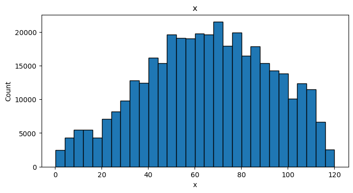

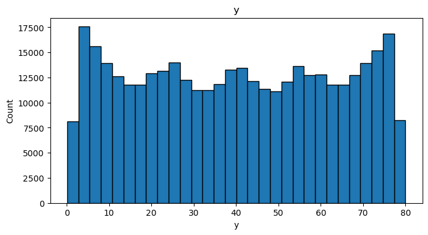

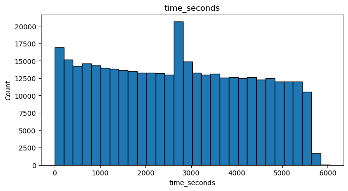

```
==============================
under_pressure_clean
0    90.864932
1     9.135068
Name: proportion, dtype: float64
```

```python
# Histogram to see numeric distribution

# Dropping under_pressure_clean for histogram
hist_model_df_numeric = model_df_numeric.drop(columns = ["under_pressure_clean"])

for i in hist_model_df_numeric:
    plt.figure(figsize=(8, 4))
    plt.hist(model_df_numeric[i], bins = 30, edgecolor = "black")
    plt.xlabel(i)
    plt.ylabel("Count")
    plt.title(i)
    plt.show()

print("=" * 30)

# Percentages of under_pressure_clean
print(model_df["under_pressure_clean"].value_counts(normalize=True) * 100)
```

##### The spatial distribution shows that actions are more concentrated in the middle areas of the pitch along X (horizontally). Along Y (vertically), actions appear more frequent in the wider areas than in the central channel.

##### The number of actions is pretty even throughout the game, with an increase during the middle of the match.

##### Around 9.13% of actions happened while players were under pressure.

```python
#Grouping foul_won with numerical variables
model_df.groupby("foul_won")[["x", "y", "time_seconds", "under_pressure_clean"]].mean()
```

| foul_won | x | y | time_seconds | under_pressure_clean |
| --- | --- | --- | --- | --- |
| 0 | 65.275553 | 39.932403 | 2704.307507 | 0.086364 |
| 1 | 61.423944 | 39.665891 | 2855.466143 | 0.368055 |

##### The average time in which a foul is won is around the middle of the game, as match has around 5500 to 6000 seconds.

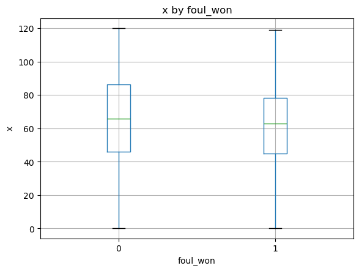

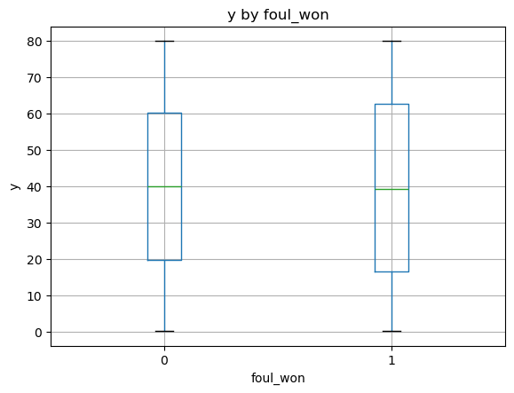

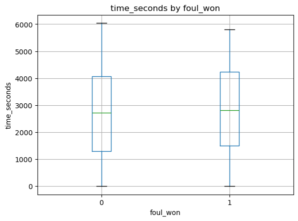

```python
# Box plot to better see median values where fouls happened
for i in ["x", "y", "time_seconds"]:
    plt.figure(figsize = (6, 4))
    model_df.boxplot(column = i, by = "foul_won")
    plt.title(f"{i} by foul_won")
    plt.suptitle("")
    plt.xlabel("foul_won")
    plt.ylabel(i)
    plt.show()
```

##### It is possible to state that the boxplot analysis did not provide much information. Each Boxplot clearly overlap with each other, meaning that the numeric variables do not individually separate the target very well. Since fouls are rare events, numerical spread is not meaningful to extract information.

##### The histogram analysis tells us more, as we can see when events are happening throughout the match.

```python
# Analyzing foul rates by binned numerical values

model_df["x_bin"] = pd.cut(model_df["x"], bins = 10)
model_df["y_bin"] = pd.cut(model_df["y"], bins = 10)
model_df["time_bin"] = pd.cut(model_df["time_seconds"], bins = 10)

# Grouping by foul_won
# There are no negatives,
# Bins are created in equal-width and has extended the first interval to fit the smallest value
print(model_df.groupby("x_bin", observed=False)["foul_won"].agg(["count", "mean"]))
print(model_df.groupby("y_bin", observed=False)["foul_won"].agg(["count", "mean"]))
print(model_df.groupby("time_bin", observed=False)["foul_won"].agg(["count", "mean"]))

# Count = how many events are in that category
# Mean = foul-winning rate for that category
```

```
                  count      mean
x_bin
(-0.0199, 12.09]  12250  0.010286
(12.09, 24.08]    16895  0.017757
(24.08, 36.07]    30750  0.019024
(36.07, 48.06]    44008  0.021155
(48.06, 60.05]    57778  0.021029
(60.05, 72.04]    60850  0.020887
(72.04, 84.03]    54352  0.020570
(84.03, 96.02]    47485  0.014952
(96.02, 108.01]   36234  0.010763
(108.01, 120.0]   20665  0.004984
                count      mean
y_bin
(0.0201, 8.09]  41282  0.020808
(8.09, 16.08]   38321  0.020928
(16.08, 24.07]  37884  0.017263
(24.07, 32.06]  37496  0.016535
(32.06, 40.05]  36393  0.013052
(40.05, 48.04]  36944  0.012911
(48.04, 56.03]  36877  0.015972
(56.03, 64.02]  37329  0.018591
(64.02, 72.01]  38440  0.020421
(72.01, 80.0]   40301  0.019702
                  count      mean
time_bin
(-6.045, 604.5]   46389  0.013926
(604.5, 1209.0]   42951  0.016367
(1209.0, 1813.5]  40891  0.016947
(1813.5, 2418.0]  39824  0.017979
(2418.0, 3022.5]  48454  0.018616
(3022.5, 3627.0]  39468  0.019053
(3627.0, 4231.5]  37608  0.017390
(4231.5, 4836.0]  37460  0.018713
(4836.0, 5440.5]  35980  0.019761
(5440.5, 6045.0]  12242  0.022137
```

##### The binned analysis is probably the most informative one thus far. For each bin, time or location, we can see the number of occurances and how often did fouls happen inside each interval. Since foul_won is a binary variable, the mean is the rate in which a foul happened.

##### For X (horizontal; 0-120), fouls happened more often between 36.07 and 84.03. This is the middle of the pitch, in which physical battle happen often and with less danger to close free kicks. The rate decreases singificantly near the attacking goal. This suggests that pitch depth is related to foul-winning probability.

##### For Y (Vertical, 0-80), fouls happen way more often on the extremes of the pitch. They happen more often between 0 and 16 & 64 and 80. The extremities are also areas in which the goal is further away, so it is less harmful to foul, and the sidelines limits space between actions and players.

##### Time is interesting. The further into the match, rates increase. This can show that players are more tired and commit more fouls by being physical but more reckless.

```python
# Categorical Analysis

# Checking for NaNs

for col in model_df_categorical:
    print(col, model_df_categorical[col].isna().mean())
```

```
pitch_area_x 0.0
pitch_side_y 0.0
match_period 0.0
referee 0.0
type.name 0.0
position.name 0.0
team.name 0.0
```

```python
# Percentage of how often each category appears

for i in model_df_categorical:
    print(model_df_categorical[i].value_counts(normalize=True))
```

```
pitch_area_x
middle third       0.492670
final third        0.318425
defensive third    0.188904
Name: proportion, dtype: float64
pitch_side_y
upper side    0.343497
lower side    0.340271
center        0.316232
Name: proportion, dtype: float64
match_period
first half     0.511584
second half    0.488416
Name: proportion, dtype: float64
referee
Mike Dean           0.086792
Mark Clattenburg    0.080778
Anthony Taylor      0.080660
Martin Atkinson     0.074242
Craig Pawson        0.074195
Mike Jones          0.072264
Robert Madley       0.069796
Roger East          0.068105
Michael Oliver      0.068102
Jonathan Moss       0.066347
Andre Marriner      0.064716
Lee Mason           0.057479
Kevin Friend        0.051961
Neil Swarbrick      0.047103
Stuart Attwell      0.010714
Paul Tierney        0.010035
Graham Scott        0.010003
Keith Stroud        0.004577
Simon Hooper        0.002130
Name: proportion, dtype: float64
type.name
Ball Receipt*    0.892613
Ball Recovery    0.107387
Name: proportion, dtype: float64
position.name
```

[output cut: 32 more lines]

```
Everton                 0.054421
Swansea City            0.054038
AFC Bournemouth         0.052399
Stoke City              0.048619
Southampton             0.048473
Aston Villa             0.046188
West Ham United         0.045991
Newcastle United        0.045921
Norwich City            0.044882
Watford                 0.044473
Crystal Palace          0.042427
Leicester City          0.040588
Sunderland              0.039631
West Bromwich Albion    0.037714
Name: proportion, dtype: float64
```

```python
# Grouping by foul_won

for i in model_df_categorical:
    print(model_df.groupby(i)["foul_won"].agg(["count", "mean"]))

# Count = how many events are in that category
# Mean = foul-winning rate for that category
```

```
                  count      mean
pitch_area_x
defensive third   72023  0.017772
final third      121405  0.012339
middle third     187839  0.021140
               count      mean
pitch_side_y
center        120569  0.014075
lower side    129734  0.019170
upper side    130964  0.019586
               count      mean
match_period
first half    195050  0.016606
second half   186217  0.018849
                  count      mean
referee
Andre Marriner    24674  0.016738
Anthony Taylor    30753  0.018892
Craig Pawson      28288  0.017534
Graham Scott       3814  0.017567
Jonathan Moss     25296  0.017157
Keith Stroud       1745  0.026934
Kevin Friend      19811  0.019232
Lee Mason         21915  0.017614
Mark Clattenburg  30798  0.017501
Martin Atkinson   28306  0.018371
Michael Oliver    25965  0.017755
Mike Dean         33091  0.017648
Mike Jones        27552  0.017276
Neil Swarbrick    17959  0.016037
Paul Tierney       3826  0.020648
Robert Madley     26611  0.016647
Roger East        25966  0.017870
Simon Hooper        812  0.032020
Stuart Attwell     4085  0.015667
                count      mean
type.name
Ball Receipt*  340324  0.015318
Ball Recovery   40943  0.037516
                           count      mean
```

[output cut: 54 more lines]

```
Everton               20749  0.017398
Leicester City        15475  0.020743
Liverpool             22187  0.014693
Manchester City       23338  0.015254
Manchester United     22560  0.014450
Newcastle United      17508  0.017763
Norwich City          17112  0.015252
Southampton           18481  0.017045
Stoke City            18537  0.017101
Sunderland            15110  0.020979
Swansea City          20603  0.017619
Tottenham Hotspur     21304  0.015913
Watford               16956  0.018224
West Bromwich Albion  14379  0.020446
West Ham United       17535  0.021101
```

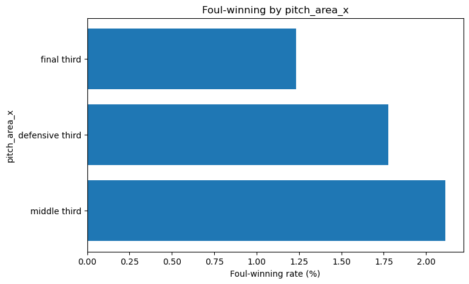

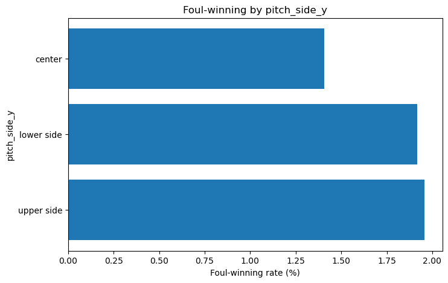

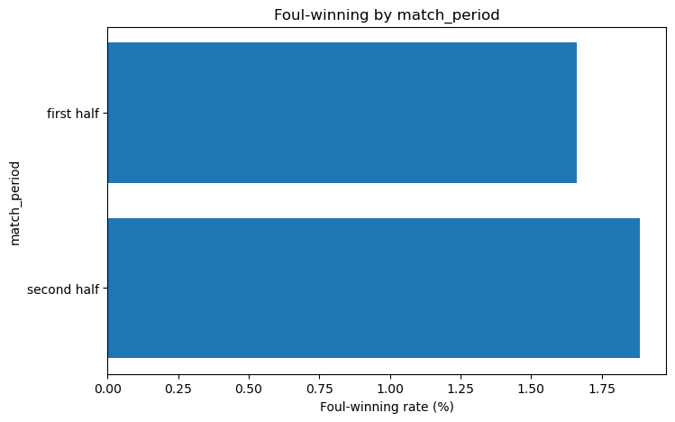

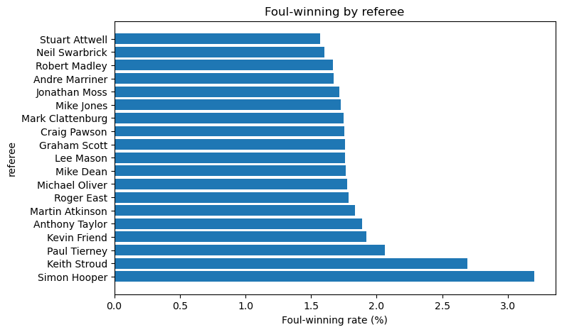

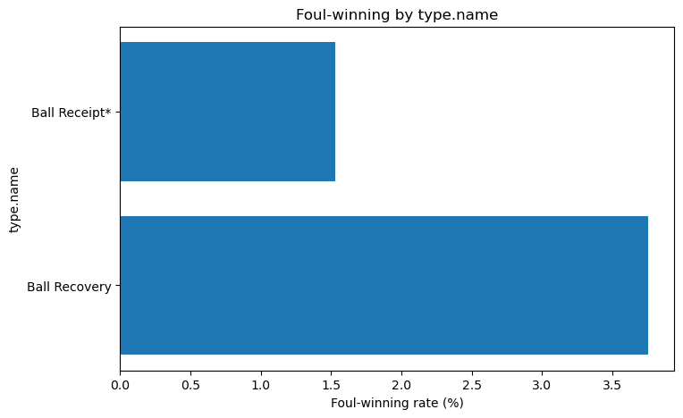

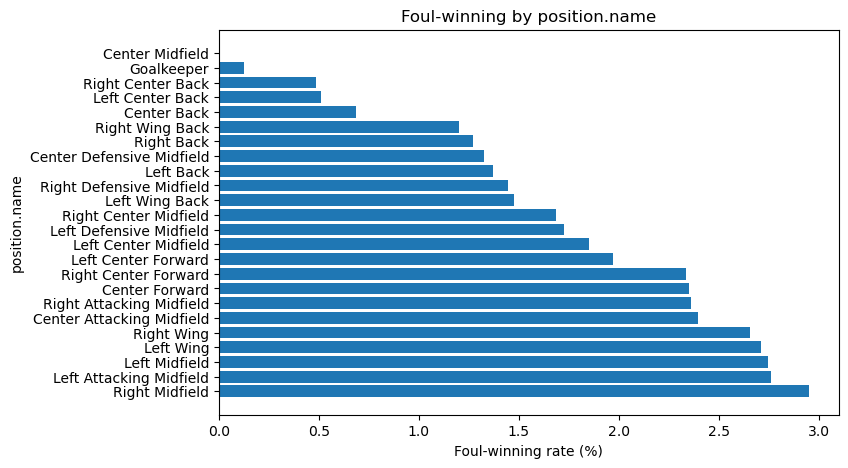

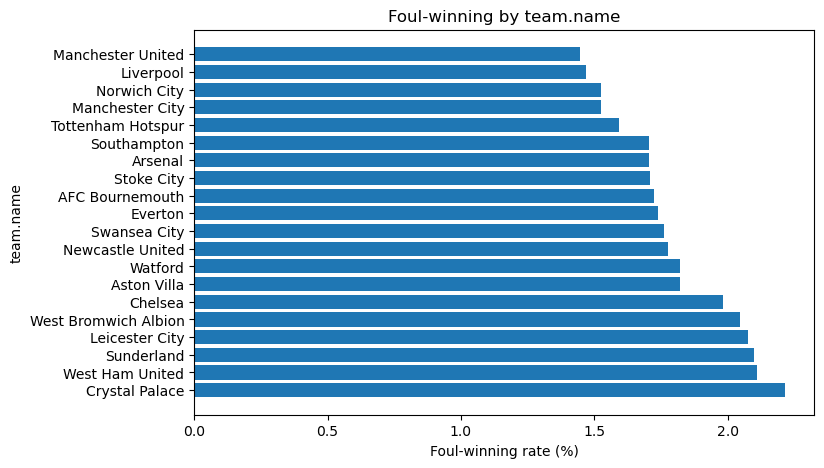

```python
# Bar chart with target rate by category

for i in model_df_categorical:
    grouped_foul = (model_df.groupby(i)["foul_won"].agg(["count", "mean"]).sort_values("mean", ascending = True))
    grouped_foul["mean_pct"] = grouped_foul["mean"] * 100

    plt.figure(figsize = (8, 5))
    plt.barh(grouped_foul.index, grouped_foul["mean_pct"])
    plt.xlabel("Foul-winning rate (%)")
    plt.ylabel(i)
    plt.title(f"Foul-winning by {i}")
    plt.gca().invert_yaxis()
    plt.show()
```

##### Main Findings:

- Categorical analysis matches the numerical analysis: Many numerical findings appear again in the categorical analysis.
- Ball Recovery is twice as likely to lead to a foul than ball reception.
- Middle of the pitch is the most likely area for a foul to occur.
- The sides of the pitch also have a higher foul rate than the center.
- The position of players play a large role, as attacking players have a higher likelihood of receiving a foul than defensive players.
- Second-half events have slightly higher foul rates

# Model Training: Predicting Foul-Winning Probability

```python
# Create a model ready df to fit into the model

numeric_variables = []
categorical_variables = []
id_variables = []

for i in model_df_numeric:
    numeric_variables.append(i)

for i in model_df_categorical:
    categorical_variables.append(i)

for i in model_df_ids:
    id_variables.append(i)

model_ready_df = model_df[id_variables + numeric_variables + categorical_variables + ["foul_won"]]

print(model_ready_df.sample(5).T)
```

```
                                                    355566  \
id                    b149a39d-f682-477f-87bf-1a338e945e44
match_id                                           3754319
x                                                     81.5
y                                                     43.1
time_seconds                                          2297
under_pressure_clean                                     0
pitch_area_x                                   final third
pitch_side_y                                        center
match_period                                    first half
referee                                      Jonathan Moss
type.name                                    Ball Receipt*
position.name                                    Left Wing
team.name                                     Swansea City
foul_won                                                 0

                                                    97785   \
id                    4cdc06a5-278b-4acf-8e30-bee8a1828f40
match_id                                           3754178
x                                                     80.0
y                                                     13.6
time_seconds                                          3196
under_pressure_clean                                     0
pitch_area_x                                   final third
pitch_side_y                                    upper side
match_period                                   second half
referee                                          Lee Mason
type.name                                    Ball Receipt*
position.name                                   Right Wing
team.name                                      Aston Villa
foul_won                                                 0

                                                    323379  \
id                    93eab157-845a-450e-b981-d27f404615c6
match_id                                           3754253
x                                                     91.6
y                                                     41.6
time_seconds                                          4968
under_pressure_clean                                     0
pitch_area_x                                   final third
```

[output cut: 24 more lines]

```
                                                    343891
id                    7f2c0ddd-8a48-4099-affa-e8c3af6e0532
match_id                                           3754299
x                                                     94.2
y                                                     31.6
time_seconds                                          4232
under_pressure_clean                                     0
pitch_area_x                                   final third
pitch_side_y                                        center
match_period                                   second half
referee                                     Andre Marriner
type.name                                    Ball Receipt*
position.name                               Center Forward
team.name                                          Everton
foul_won                                                 0
```

```python
# Creating X and y for the model

X = model_ready_df[numeric_variables + categorical_variables]
y = model_ready_df["foul_won"]

print(X.shape)
print(y.shape)
```

```
(381267, 11)
(381267,)
```

```python
# Importing necessary libraries for a logistic regression and preprocessing to fit the model
from sklearn.compose import ColumnTransformer
from sklearn.preprocessing import OneHotEncoder, StandardScaler
from sklearn.pipeline import Pipeline
from sklearn.linear_model import LogisticRegression
from sklearn.model_selection import train_test_split
```

```python
# Separating numerical features by continuous and binary (for scaling)

continuous_features = ["x", "y", "time_seconds"]
binary_features = ["under_pressure_clean"]
categorical_features = categorical_variables
```

```python
# Creating the preprocessor

preprocessor = ColumnTransformer(transformers = [("continuous", StandardScaler(), continuous_features),
                                                 ("categorical", OneHotEncoder(handle_unknown="ignore"), categorical_features),
                                                 ("binary", "passthrough", binary_features)])
```

```python
# Creating the pipeline

log_reg_pipeline = Pipeline(steps = [("preprocessor", preprocessor), ("model", LogisticRegression(max_iter=1000))])
```

```python
# Train-test split

X_train, X_test, y_train, y_test = train_test_split(X, y, test_size = 0.2, random_state= 42, stratify= y) # Using 20% for testing

# Printing the proportion of foul_won in the train and test sets
# Around 1.7% of the full dataset has foul_won = 1
# So we check if both splits kept a similar target distribution
print(y_train.mean())
print(y_test.mean())
```

```
0.017700884880316577
0.017703989298922022
```

```python
# Train the logistic regression pipeline

log_reg_pipeline.fit(X_train, y_train)
```

```
Pipeline(steps=[('preprocessor',
                 ColumnTransformer(transformers=[('continuous',
                                                  StandardScaler(),
                                                  ['x', 'y', 'time_seconds']),
                                                 ('categorical',
                                                  OneHotEncoder(handle_unknown='ignore'),
                                                  ['pitch_area_x',
                                                   'pitch_side_y',
                                                   'match_period', 'referee',
                                                   'type.name', 'position.name',
                                                   'team.name']),
                                                 ('binary', 'passthrough',
                                                  ['under_pressure_clean'])])),
                ('model', LogisticRegression(max_iter=1000))])
```

# Model Evaluation: Probability Quality and Performance

```python
# Probability prediciton for foul_won = 1

y_pred_probability = log_reg_pipeline.predict_proba(X_test)[:, 1]
y_pred_probability[:10]
```

```
array([0.00999708, 0.01579569, 0.01510451, 0.01557721, 0.00313112,
       0.01264088, 0.01383812, 0.0164354 , 0.00898192, 0.0070916 ])
```

##### These 10 probabilities are a peek of the range in which the probabilities can reach. As foul_won = 1 is a rare event which occured only 1.7% of the time, low probabilities are coherent to the scope of the target.

```python
# Evaluating probability quality and ranking performance
from sklearn.metrics import roc_auc_score, log_loss, brier_score_loss

roc_auc = roc_auc_score(y_test, y_pred_probability)
logloss = log_loss(y_test, y_pred_probability)
brier = brier_score_loss(y_test, y_pred_probability)

print("ROC AUC:", roc_auc)
print("Log Loss:", logloss)
print("Brier Score:",brier)
```

```
ROC AUC: 0.7651081680847781
Log Loss: 0.07991419789134856
Brier Score: 0.016923466473266424
```

#### Interpretation:

##### ROC AUC measures how well the model ranks foul-winning events. A value above 0.50 means that the model evaluates the probabilities better than randomly guessing foul_won. Since the target is very imbalanced, the model does not need high probabilities but accurate ranking.

##### Log Loss measures if a model is confidently getting the wrong answer or not. If it is, log loss becomes an incredibly high number. Since log loss is very small (around 0.07), it states that the model is doing a good job in predicting realistic probabilites and it is not being confidently wrong.

##### Brier Score calculates the overall precision of the prediceted probabilities, line by line. It is useful to fine tune the model and see if the probabilities are linearly and significantly different.

##### In this dataset, in which fouls are a rare event, ROC AUC is the main indicator of success. While having small log loss and Brier scores, since the data is very imbalanced (1.7% of foul_won = 1), if the model predicted all 0s, log loss and Brier would be small nontheless. ROC AUC states that we have 76.5% of chance of attributing a more correct probability to a foul event rather than a non-foul event. It is possible to say that the model is learning from the data, and that it is understanding what situation generates a foul.

```python
# Baseline Probabilities to compare metrics

baseline_prob = y_train.mean()

baseline_pred = np.full_like(y_test, fill_value=baseline_prob, dtype=float)

baseline_logloss = log_loss(y_test, baseline_pred)
baseline_brier = brier_score_loss(y_test, baseline_pred)

print("Baseline Log Loss:", baseline_logloss)
print("Baseline Brier Score:", baseline_brier)
```

```
Baseline Log Loss: 0.08896361901369296
Baseline Brier Score: 0.017390558071463086
```

##### Here, a comparison was made to the baseline porbabilities, and log loss and Brier Score were small. This does not informs much, as the foul_won = 1 event is very rare.

# Feature Engineering Addition + Random Forest/XGBoost modeling

##### The initial model was interesting and the ROC AUC results portrayed that, but there is room for improvement. Two additional features are going to be added and Random Forest & XGBoost models are going to be used.

```python
# Checking duration & play_pattern.name for NaNs

model_df[["duration", "play_pattern.name"]].isna().mean()
```

```
duration             0.892613
play_pattern.name    0.000000
dtype: float64
```

##### It is possible to see that duration is almost entirelly Null, which is explained by the filter used to focus on Ball Receipt and Ball Recovery. Many of the events were cutoff and much of these are instantaneous events (hence filled as null). The metric that will be created is if there was duration during an event or not (binary), as events with duration can have higher physicality probabilities.

```python
# Creating a column with a binary variable (0/1) to indicate if an event has a duration or not

model_df["has_duration"] = model_df["duration"].notna().astype(int)

model_df["has_duration"].sample(5)
```

```
106927    0
116209    0
110339    0
270185    0
164589    0
Name: has_duration, dtype: int64
```

```python
# Check to see if has_duration has different foul_winning rates

model_df.groupby("has_duration")["foul_won"].agg(["count", "mean"])
```

| has_duration | count | mean |
| --- | --- | --- |
| 0 | 340324 | 0.015318 |
| 1 | 40943 | 0.037516 |

```python
# Cross checking if has_duration has the same information as Ball Recepit and Recovery

pd.crosstab(model_df["type.name"], model_df["has_duration"])
```

| has_duration type.name | 0 | 1 |
| --- | --- | --- |
| Ball Receipt* | 340324 | 0 |
| Ball Recovery | 0 | 40943 |

##### We can see that has_duration is just another way of saying that if the event was a Ball Receipt or Ball Recovery, so it becomes redundant to add both features - and it could even add unnecessary noise to the models. Therefore, it is not going to be added to the model.

##### it is not useless to have done such an analysis, as we can see that Ball Recovery is probably a more efficient metric to identify fouls.

```python
# Adding play_pattern.name to the categorical variables

# Taking a look at the values from the play_pattern.name column
model_df["play_pattern.name"].value_counts()
```

```
play_pattern.name
Regular Play      170203
From Throw In      97296
From Free Kick     48061
From Goal Kick     28104
From Corner        13416
From Kick Off      12845
From Keeper         7819
From Counter        3019
Other                504
Name: count, dtype: int64
```

```python
# Grouping and seeing play_pattern.name's details and value counts

model_df.groupby("play_pattern.name")["foul_won"].agg(["count", "mean"])
```

| play_pattern.name | count | mean |
| --- | --- | --- |
| From Corner | 13416 | 0.009839 |
| From Counter | 3019 | 0.089434 |
| From Free Kick | 48061 | 0.011839 |
| From Goal Kick | 28104 | 0.015692 |
| From Keeper | 7819 | 0.019951 |
| From Kick Off | 12845 | 0.011288 |
| From Throw In | 97296 | 0.013618 |
| Other | 504 | 0.009921 |
| Regular Play | 170203 | 0.021774 |

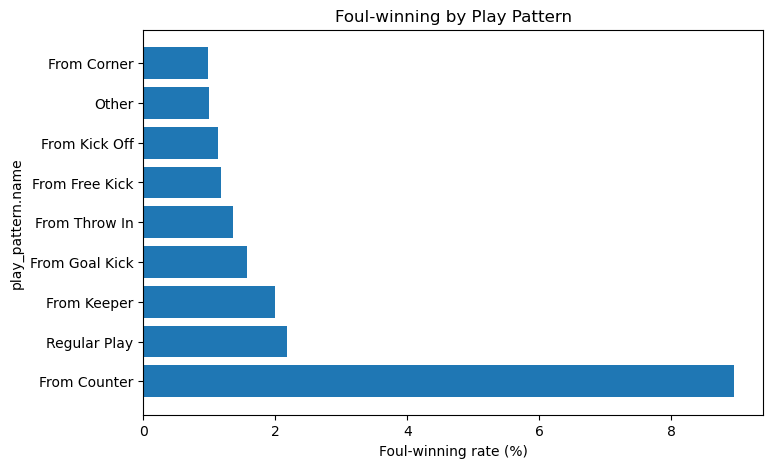

```python
# Analyze foul-winning rate by play pattern

grouped_patterns = model_df.groupby("play_pattern.name")["foul_won"].agg(["count", "mean"]).sort_values("mean", ascending = True)
grouped_patterns["mean_pct"] = grouped_patterns["mean"] * 100
plt.figure(figsize = (8, 5))
plt.barh(grouped_patterns.index, grouped_patterns["mean_pct"])
plt.xlabel("Foul-winning rate (%)")
plt.ylabel("play_pattern.name")
plt.title("Foul-winning by Play Pattern")
plt.gca().invert_yaxis()
plt.show()
```

##### The results show that From Counter is an important foul-winning play pattern. Even though counterattacks have a much smaller count compared to categories like Regular Play, they have the highest foul-winning rate by a large margin. This suggests that counters are rare, but when they happen, they create strong foul-winning opportunities.

```python
# Adding play_pattern.name to the categorical features

categorical_variables = categorical_variables + ["play_pattern.name"]
categorical_features = categorical_features + ["play_pattern.name"]
```

```python
# Recreating the X and y for the next models
# model_ready_df_v2 includes the added play_pattern.name feature

model_ready_df_v2 = model_df[id_variables + numeric_variables + categorical_variables + ["foul_won"]]

X = model_ready_df_v2[numeric_variables + categorical_variables]
y = model_ready_df_v2["foul_won"]

print(X.shape)
print(y.shape)
```

```
(381267, 12)
(381267,)
```

```python
# Train-test splitting for updated feature set

X_train, X_test, y_train, y_test = train_test_split(X, y, test_size = 0.2, random_state = 42, stratify = y)

print(y_train.mean())
print(y_test.mean())
```

```
0.017700884880316577
0.017703989298922022
```

```python
# Creating Preprocessor for the tree models
# Random Forest & XGBoost do not need scalling as logistic regression

tree_preprocessor = ColumnTransformer(transformers = [("categorical", OneHotEncoder(handle_unknown="ignore"), categorical_variables),
                                                      ("numeric", "passthrough", numeric_variables)])
```

```python
# Random Forest Pipeline

from sklearn.ensemble import RandomForestClassifier
from sklearn.pipeline import Pipeline

# Creating the RF Pipeline

rf_pipeline = Pipeline(steps = [("preprocessor", tree_preprocessor), ("model", RandomForestClassifier(n_estimators = 200, max_depth = 10,
                                                                                                      min_samples_leaf = 50, random_state = 42, n_jobs = -1,
                                                                                                      class_weight = None))])
```

```python
# Train the RF model

rf_pipeline.fit(X_train, y_train)
```

```
Pipeline(steps=[('preprocessor',
                 ColumnTransformer(transformers=[('categorical',
                                                  OneHotEncoder(handle_unknown='ignore'),
                                                  ['pitch_area_x',
                                                   'pitch_side_y',
                                                   'match_period', 'referee',
                                                   'type.name', 'position.name',
                                                   'team.name',
                                                   'play_pattern.name']),
                                                 ('numeric', 'passthrough',
                                                  ['x', 'y', 'time_seconds',
                                                   'under_pressure_clean'])])),
                ('model',
                 RandomForestClassifier(max_depth=10, min_samples_leaf=50,
                                        n_estimators=200, n_jobs=-1,
                                        random_state=42))])
```

```python
# Predict probability of foul_won = 1

rf_pred_probability = rf_pipeline.predict_proba(X_test)[:, 1]
```

```python
# Inpsect first few rows

rf_pred_probability[:10]
```

```
array([0.01292954, 0.01307038, 0.02091758, 0.01953425, 0.00734901,
       0.01264434, 0.01286336, 0.01890636, 0.02037064, 0.00828839])
```

```python
from sklearn.metrics import average_precision_score

# Evaluating RF Probability Predictions

print("Random Forest ROC AUC:", roc_auc_score(y_test, rf_pred_probability))
print("Random Forest Average Precision", average_precision_score(y_test, rf_pred_probability))
print("Random Forest Log Loss:", log_loss(y_test, rf_pred_probability))
print("Random Forest Brier Score:", brier_score_loss(y_test, rf_pred_probability))
```

```
Random Forest ROC AUC: 0.7740851153674234
Random Forest Average Precision 0.08077286768546728
Random Forest Log Loss: 0.07999732691186605
Random Forest Brier Score: 0.016910055264495658
```

##### Log Loss & Brier Score once again are small, but, since the target is imbalanced, it is not necessarily an amazing evaluation metric.

##### The ROC AUC increased compared to the logistic regression model, which suggests that the Random Forest improved the model’s ranking performance. Since ROC AUC measures how well the model separates foul-winning events from non-foul events, this improvement indicates that the Random Forest is learning useful patterns from the features and performing better than random guessing.

##### The Average Precision metric showed that the model is around 4.5x (0.0807/0.0177 ≈ 4.56) better than just randomly ranking foul events. This is especially meaningful, as we can confidently say that the model is capable of concentrating real fouls near the top of the predicted-probability ranking. The result looks small (0.0807), but, since the target rate (0.0177) is very small, this value makes sense.

```python
# Now we use the same preprocessor & features for the XGBoost model

from xgboost import XGBClassifier

xgb_pipeline = Pipeline(steps = [("preprocessor", tree_preprocessor), ("model", XGBClassifier(n_estimators = 300, max_depth = 4,
                                                                                              learning_rate = 0.05, subsample = 0.8,
                                                                                              colsample_bytree = 0.8, eval_metric = "logloss",
                                                                                              random_state = 42, n_jobs = -1))])
```

```python
# Training XGBoost model

xgb_pipeline.fit(X_train, y_train)
```

```
Pipeline(steps=[('preprocessor',
                 ColumnTransformer(transformers=[('categorical',
                                                  OneHotEncoder(handle_unknown='ignore'),
                                                  ['pitch_area_x',
                                                   'pitch_side_y',
                                                   'match_period', 'referee',
                                                   'type.name', 'position.name',
                                                   'team.name',
                                                   'play_pattern.name']),
                                                 ('numeric', 'passthrough',
                                                  ['x', 'y', 'time_seconds',
                                                   'under_pressure_clean'])])),
                ('model',
                 XGBClassifier(base_score=Non...
                               feature_types=None, feature_weights=None,
                               gamma=None, grow_policy=None,
                               importance_type=None,
                               interaction_constraints=None, learning_rate=0.05,
                               max_bin=None, max_cat_threshold=None,
                               max_cat_to_onehot=None, max_delta_step=None,
                               max_depth=4, max_leaves=None,
                               min_child_weight=None, missing=nan,
                               monotone_constraints=None, multi_strategy=None,
                               n_estimators=300, n_jobs=-1,
                               num_parallel_tree=None, ...))])
```

```python
# Predicting the probability of foul_won = 1

xgb_pred_probability = xgb_pipeline.predict_proba(X_test)[:, 1]

xgb_pred_probability[:10]
```

```
array([0.01063053, 0.01181224, 0.01947   , 0.02103191, 0.00299645,
       0.01028252, 0.00997676, 0.01559493, 0.01533954, 0.00806347],
      dtype=float32)
```

```python
# Evaluating XGBoost probability prediction

print("XGBoost ROC AUC:", roc_auc_score(y_test, xgb_pred_probability))
print("XGBoost Average Precision:", average_precision_score(y_test, xgb_pred_probability))
print("XGBoost Log Loss:", log_loss(y_test, xgb_pred_probability))
print("XGBoost Brier Score:", brier_score_loss(y_test, xgb_pred_probability))
```

```
XGBoost ROC AUC: 0.779453527675919
XGBoost Average Precision: 0.0856717158531505
XGBoost Log Loss: 0.07852394610432345
XGBoost Brier Score: 0.016780807726096227
```

##### The XGBoost model performed slightly better than the Random Forest across all evaluation metrics. Both ROC AUC and Average Precision improved by a small margin, but it shows that the model captured the patterns slightly better.

##### The probability-based metrics also improved slightly. Both Log Loss and Brier Score were smaller than the Random Forest, which suggests that the probability estimates were a little better.

##### The XGBoost model was the best model thus far, not by a big margin though. The Random Forest model was already strong, but XGBoost still provided a small improvement in both ranking performance and probability quality.

# Model Comparison, Feature Importance & Final Remarks

```python
# Tabling each model's metrics, for better visualization of the differences between LR, RF and XGB

model_results = pd.DataFrame({
    "model": ["Logistic Regression", "Random Forest", "XGBoost"],
    "roc_auc": [
        roc_auc_score(y_test, y_pred_probability),
        roc_auc_score(y_test, rf_pred_probability),
        roc_auc_score(y_test, xgb_pred_probability)
    ],
    "average_precision": [
        average_precision_score(y_test, y_pred_probability),
        average_precision_score(y_test, rf_pred_probability),
        average_precision_score(y_test, xgb_pred_probability)
    ],
    "log_loss": [
        log_loss(y_test, y_pred_probability),
        log_loss(y_test, rf_pred_probability),
        log_loss(y_test, xgb_pred_probability)
    ],
    "brier_score": [
        brier_score_loss(y_test, y_pred_probability),
        brier_score_loss(y_test, rf_pred_probability),
        brier_score_loss(y_test, xgb_pred_probability)
    ]
})

print(model_results)
```

```
                 model   roc_auc  average_precision  log_loss  brier_score
0  Logistic Regression  0.765108           0.071538  0.079914     0.016923
1        Random Forest  0.774085           0.080773  0.079997     0.016910
2              XGBoost  0.779454           0.085672  0.078524     0.016781
```

```python
# Getting feature names after preprocessing

feature_names = xgb_pipeline.named_steps["preprocessor"].get_feature_names_out()

# Getting XGBoost feature importances

importances = xgb_pipeline.named_steps["model"].feature_importances_

feature_importance_df = pd.DataFrame({"feature": feature_names, "importance": importances}).sort_values("importance", ascending = False)

feature_importance_df.head(20)
```

|  | feature | importance |
| --- | --- | --- |
| 85 | numeric__under_pressure_clean | 0.211103 |
| 74 | categorical__play_pattern.name_From Counter | 0.048425 |
| 28 | categorical__type.name_Ball Recovery | 0.046150 |
| 1 | categorical__pitch_area_x_final third | 0.041151 |
| 46 | categorical__position.name_Right Center Back | 0.036576 |
| 34 | categorical__position.name_Goalkeeper | 0.034764 |
| 37 | categorical__position.name_Left Center Back | 0.034392 |
| 27 | categorical__type.name_Ball Receipt* | 0.026704 |
| 81 | categorical__play_pattern.name_Regular Play | 0.024852 |
| 50 | categorical__position.name_Right Midfield | 0.019076 |
| 42 | categorical__position.name_Left Wing | 0.018739 |
| 51 | categorical__position.name_Right Wing | 0.014974 |
| 32 | categorical__position.name_Center Forward | 0.014450 |
| 82 | numeric__x | 0.013295 |
| 45 | categorical__position.name_Right Back | 0.011499 |
| 41 | categorical__position.name_Left Midfield | 0.010447 |
| 3 | categorical__pitch_side_y_center | 0.010291 |
| 2 | categorical__pitch_area_x_middle third | 0.010190 |
| 59 | categorical__team.name_Leicester City | 0.008776 |
| 29 | categorical__position.name_Center Attacking Mi... | 0.008731 |

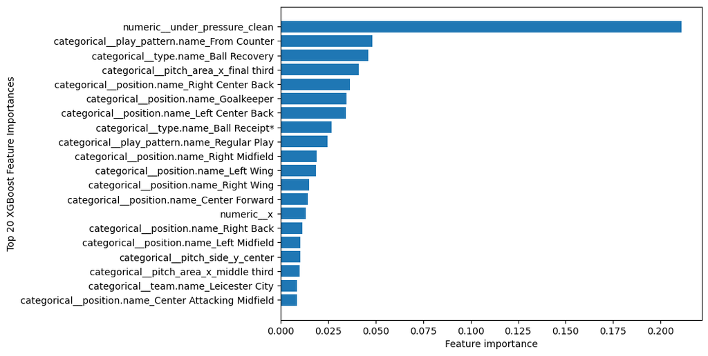

```python
# Plotting most important features

top_features = feature_importance_df.head(20).sort_values("importance", ascending = True)

plt.figure(figsize=(8, 6))
plt.barh(top_features["feature"], top_features["importance"])
plt.xlabel("Feature importance")
plt.ylabel("Top 20 XGBoost Feature Importances")
plt.show()
```

##### This project aimed to create a model that predicted the probability that a player would win a foul when a player received or recovered the ball. Since foul events are rare, accuracy was not the main metric used to evaluate the models. The models were evaluated using ROC AUC, Log Loss, Average Precision and Brier Score.

##### The EDA showed that foul-winning probability changes depending on event context. Events under pressure, Ball Recovery, pitch zones, player position and counterattacks were associated with higher foul-winning rates.

##### By the features table, we can see that the under pressure feature was the most important feature in the XGBoost model by far, followed by Counter attacks, Ball Recovery and Final Third. Remembering that feature importance does not necesserily imply causation, but what the model used the most to evaluate probabilities.

##### Pitch area and position also play an important part in foul-winning rates, as some positions engage in more physical battles and some pitch areas have less goal danger.

##### Overall, the feature-importance analysis' results are consistent to the EDA. The XGBoost seemed to rely on events such as pressure, play patterns, event type, pitch area and player position.